# 9 Distribution d’échantillonnage

- Montrer tout le code
- Cacher tout le code

Auteur

Affiliation

Daniel Coulombe

Institut des Sciences, Technologies et Études Avancées d’Haïti (ISTEAH)

Date

05/04/2024

Que peut-on apprendre en tirant un nombre infini d’échantillons d’une population dont les paramètres sont connus?

Cette question nous conduit directement au coeur le l’inférence statistique. Tenter d’y répondre nous permettra de jeter les bases de l’ensemble des stratégies permettant d’en connaître un peu plus sur les paramètres d’une population donnée.

## 9.1 Le contexte

On s’intéresse à une population d’observations dont on connait les caractéristiques essentielles: la forme de la distribution (uniforme, Gaussienne, Exponentielle, etc), la moyenne et la variance/écart-type. De cette population, on tire un grand nombre d’échantillons desquels on obtient une statistique échantillonnale (moyenne, variance, proportion, médiane, etc.). Notre attention se porte alors sur les caractéristiques de l’ensemble des statistiques échantillonnales obtenues. Donc essentiellement, on part d’une population dont on connait les paramètres, et on étudie ce qui pourrait se produire si on tire des échantillons de cette population.

Dans les démonstrations et exercices présentés dans la section précédente, il devrait être acquis que les statistiques calculées pour un échantillon seront très probablement différentes de celles calculées pour un autre échantillon. Étant donné que la sélection des sujets composant un échantillon se fait de manière aléatoire, différents échantillons seront composés de sujets différents. Et puisque les statistiques échantillonnales utilisent les informations fournies par ces sujets, leur variation est un fait avéré.

Puisque les statistiques échantillonnales sont le résultat d’une expérience aléatoire, on peut les considérer de la même manière qu’on l’a fait pour des observations obtenues d’un sujet particulier. Donc, on peut tracer la distribution d’une statistique donnée (moyenne, médiane, écart-type, consensus, etc.) calculée pour un très grand nombre d’échantillons. Cette distribution porte le nom de: **distribution d’échantillonnage** de la statistique qui la compose.

Ces distributions sont en quelque sorte la substance vitale de l’inférence statistique! Sans elles, aucune inférence concernant un paramètre d’une population n’est possible. C’est donc sans surprise que l’essentiel des procédures d’analyse inférentielle de données gravite autour de la détermination de leurs caractéristiques.

Dans le présent chapitre, nous abordons l’étude de distributions d’échantillonnage de deux manières:

1. **par voie de simulation**: nous disposons de populations et de la technologie nécessaire pour en extraire des échantillons. Les instruments informatiques nous permettront d’échantillonner une population autant de fois qu’il sera nécessaire de le faire pour nous permettre de spécifier différentes caractéristiques des distributions d’échantillonnage. Cette approche est privilégiée dans un premier temps, dans le présent document. Il s’agit d’une approche **empirique**.
2. **par voie analytique**: en supposant que certaines conditions ou postulats sont respectés, il est possible, dans certains cas, d’obtenir la spécification de différentes caractéristiques des distributions d’échantillonnage en utilisant des énoncés mathématiques, ou équations définissant ces caractéristiques. Cette approche est privilégiée dans la plupart des exposés d’introduction aux méthodes quantitatives. Cette approche est dite **théorique**.

La Figure 9.1 illustre les deux approches à l’examen de distributions de probabilités.

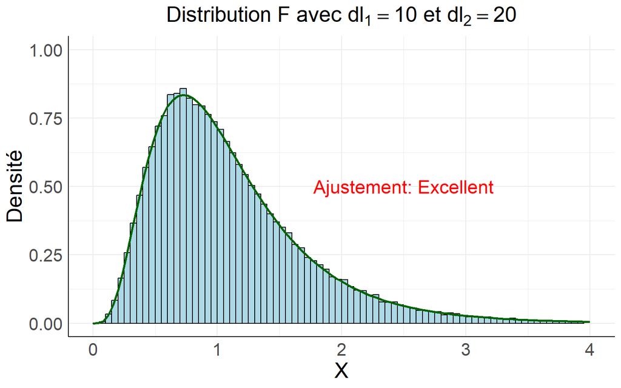

Figure 9.1: Distribution empirique (histogramme) versus distribution théorique (courbe en vert). La distribution empirique est obtenue à partir des données, alors que la distribution théorique est construite à partir de formulations mathématiques. Si les deux distributions s’ajustent bien, les probabilités obtenues de l’une seront comparables à celles obtenues de l’autre.

Dans cette figure, on représente les données observées pour un ensemble d’entités. La hauteur des barres est proportionnelle à la fréquence relative (proportion/probabilité) des valeurs possibles. On peut y percevoir une forme générale présentant des irrégularités, toutes résultantes de la nature aléatoire des données recueillies. À cet histogramme, on superpose une courbe définie par une formulation mathématique qui elle aussi, pour autant que l’ajustement par rapport aux données empiriques est adéquat, peut permettre le calcul des probabilités. Ces calculs seront au moins approximativement exacts si vraiment l’ajustement entre la fonction théorique et les données empiriques est bon. Ce ne serait pas le cas pour la distribution illustrée dans la Figure 9.2:

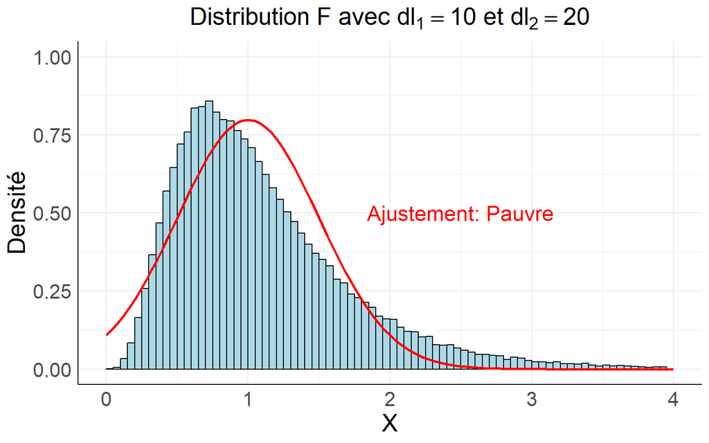

Figure 9.2: Distribution empirique (histogramme) versus distribution théorique (courbe en rouge). La distribution théorique ne semble pas suivre les données empiriques de près. L’utilisation de la distribution théorique pour le calcul de probabilités fournirait des estimations erronées.

Le degré d’accord entre la distribution théorique et la distribution empirique est relativement faible. Les caractéristiques du modèle théorique ne correspondent pas aux caractéristiques des données empiriques. En calculant des probabilités à partir de la distribution empirique fournirait des réponses exactes, mais l’utilisation de la distribution théorique fournirait des réponses erronées. Pour utiliser cette dernière distribution, il faudra donc s’assurer de la qualité de l’ajustement par rapport aux données empiriques. La précision des probabilités obtenues sera donc **conditionnelle** au respect de différents **postulats** qui dépendent du type de données analysées.

Une compréhension du matériel présenté ici est essentielle et préalable à tout ce qui sera abordé non seulement dans les chapitres suivants, mais aussi dans toutes les formations en méthodes quantitatives qu’on sera amené à entreprendre à l’avenir. Il est donc important d’y apporter une attention particulière!

## 9.2 Distribution d’échantillonnage d’une moyenne: Grands échantillons

Supposons une population infinie, dont la distribution est uniforme avec des valeurs comprises entre 0 et 10. On tire de cette population, un échantillon de 25 observations (**x = runif(25,0,10)**). Finalement, on calcule la moyenne des données recueillies auprès de cet échantillon (**moy = mean(x)** ):

```r
x <- runif(25,0,10)
moy <- mean(x)
```

$$\bar{X}=5.373$$

Tirons de cette même population, un second échantillon de même taille:

```r
x <-  runif(25,0,10)
moy <-  mean(x)
```

$$\bar{X}=4.781$$

La variation de la statistique échantillonnale (la moyenne) est évidente. Répétons cette expérience 10,000 fois, en tirant à chaque fois un nouvel échantillon de 25 sujets. La procédure implique quatre étapes:

1. Tirer un échantillon de *n* = 25 observations: **runif(n, 0, 10)**
2. Calculer la moyenne de cet échantillon: **mean(runif(n, 0, 10))**
3. Répéter *nrep* fois: **replicate(nrep, …)**
4. Affichage de la distribution des moyennes: **hist(dismoy, …)**

Le code R suivant effectue ces opérations, générant 10,000 échantillons de taille $n=25$. Pour chaque échantillon, on calcule la moyenne, pour finalement calculer la moyenne et l’écart-type des moyennes.

```r
nrep <- 10000
n <- 25
dismoy <- replicate(nrep, mean(runif(n, 0, 10)))
mean_val <- mean(dismoy)
sd_val <- sd(dismoy)
```

La Figure 9.3 illustre la **distribution d’échantillonnage des moyennes** obtenue de cette manière.

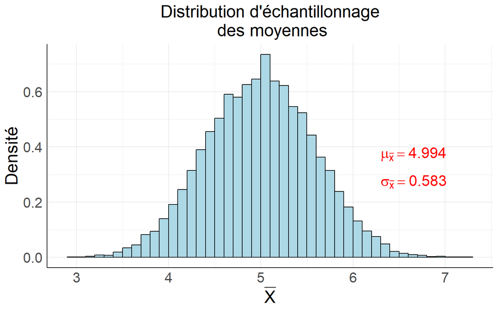

Figure 9.3: Distribution d’échantillonnage des Moyennes. Les échantillons sont de taille n = 25, tirés d’une distribution uniforme ($U_{[0, 10]}$). Le nombre d’échantillons est égal à 10,000.

```r
h <- hist(dismoy, breaks = "FD", plot = FALSE)
breaks <- h$breaks
moydat <- data.frame(dismoy)

ggplot(moydat, aes(x = dismoy)) +
  geom_histogram(breaks = breaks,
                 aes(y = after_stat(density)),
                 fill = "lightblue",
                 color = "black") +
  labs(x = TeX("$\\bar{X}$"), y = "Densité",
       title = 'Distribution d\'échantillonnage\n des moyennes') +
  theme_minimal() +
  theme(plot.title = element_text(size = 20, hjust = 0.5),
        axis.text = element_text(size = 16),
        axis.title = element_text(size = 20),
        axis.line = element_line(color = "black")) +
  annotate("text",
           x = 6.3,
           y = 0.4,
           label = TeX(paste("$\\mu_{\\bar{x}} =", round(mean_val, 3), "$")),
           hjust = 0,
           vjust = 1,
           size = 6,
           fontface = "bold",
           color = "red") +
  annotate("text",
           x = 6.3,
           y = 0.3,
           label = TeX(paste("$\\sigma_{\\bar{x}} =", round(sd_val, 3), "$")),
           hjust = 0,
           vjust = 1,
           size = 6,
           fontface = "bold",
           color = "red")
```

Dans les sections précédentes, nous avons souvent rencontré ce type de distribution, qualifiée de *Normale*. Et dans plusieurs cas, nous l’avons utilisée de manière à obtenir certaines probabilités. Dans le contexte actuel, tout ce qui a été dit demeure vrai! On peut donc répondre à certaines questions telles que:

1. En tirant un échantillon de 25 sujets de cette population, quelle est la probabilité que sa moyenne soit supérieure à 6? (la fonction Listing 9.1 permet d’illustrer les situations à l’étude)

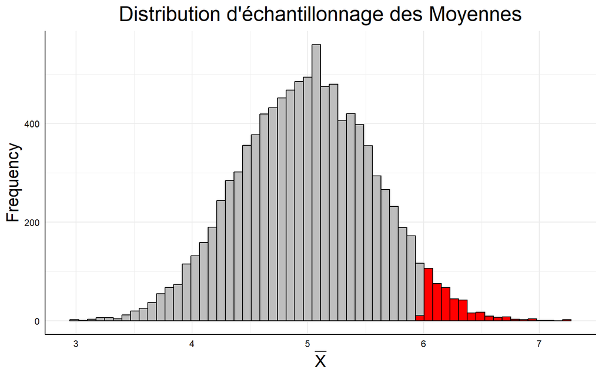

```r
DistHist(moydat$dismoy, ub=6, col="red")
```

Toutes les moyennes composant la distribution d’échantillonnage des moyennes se trouvent dans l’objet **dismoy**, que l’on peut sonder directement en comptabilisant le nombre de moyennes supérieures à 6, et en divisant ce nombre par le nombre d’échantillons tirés de la population

```r
p <- sum(dismoy>6)/nrep
```

$$P(\bar{X}>6)=\frac{414}{10000}= 0.041$$

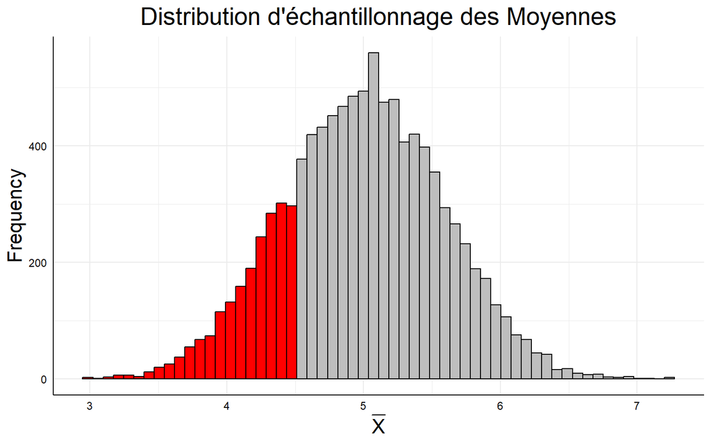

```r
DistHist(moydat$dismoy, lb=4.5, col="red")
```

```r
p <- sum(dismoy < 4.5) / nrep
```

3. En tirant des échantillons de 25 sujets de cette population, à l’intérieur de quelles limites centrales retrouve-t-on 95% des moyennes?

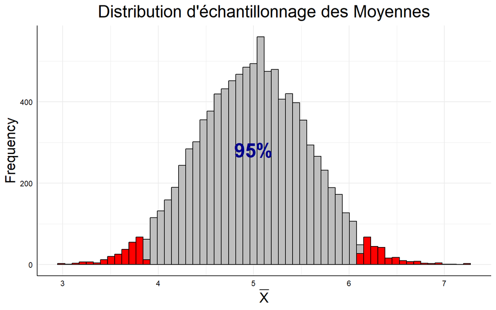

```r
DistHist(moydat$dismoy,
         lb=quantile(dismoy, 0.025),
         ub=quantile(dismoy, 0.975),
         col="red") +
  annotate("text",
           x = 5,
           y = 300,
           label = "95%",
           hjust = 0.5,
           vjust = 1,
           size = 8,
           fontface = "bold",
           color = "darkblue")
```

```
Pour répondre à cette question, on peut procéder de deux manières:
```

- En utilisant la fonction **quantile()**: cette fonction permet d’obtenir directement les percentiles recherchés:

```r
intvl = round(quantile(dismoy,c(0.025,0.975)),3)
```

$$P( 3.855 \le \bar{X} \le 6.127 = 0.95$$

- En calculant directement les limites à partir de l’ensemble des moyennes: pour obtenir l’aire centrale comprenant 95% des $\bar X$, on doit essentiellement déterminer le $2.5^{ième}$ et le $97.5^{ième}$ percentiles. Ces valeurs s’obtiennent en trouvant les valeurs de $\bar X$ occupant les positions $nrep \times 0.025$ et $nrep \times 0.975$ dans la séquence ordonnée des moyennes:

```r
li <- sort(dismoy)[nrep*(0.025)]
lu <- sort(dismoy)[nrep*(0.975)]
```

$$P( 3.853 \le \bar{X} \le 6.127 = 0.95$$

Suite à cette dernière question, on peut aisément imaginer des zones particulières, sous cette distribution:

1. une région où les moyennes ont des valeurs probables: elles sont localisées autour de la moyenne de la population. Cette zone pourrait correspondre à un intervalle tel que celui obtenu ci-dessus, où 95% des moyennes se trouvent compris entre 3.853 et 6.127 . En d’autres termes, en tirant un échantillon de *n* = 25 observations, la probabilité que sa moyenne soit comprise dans cet intervalle est égale à 0.95. Évidemment, on pourrait définir des intervalles correspondant à différents niveaux de probabilité. Pour le besoin des discussions futures, identifions cette probabilité par $(1-\alpha)$
2. Deux régions où les moyennes ont des valeurs improbables: elles sont localisées dans chacune des extrémités de la distribution d’échantillonnage. Considérant toujours $(1-\alpha)=0.95$, en tirant un échantillon de *n* = 25 observations, la probabilité que sa moyenne soit comprise dans l’une ou l’autre de ces extrémités est égale à $1-0.95 = 0.05$. Évidemment, on pourrait définir des intervalles correspondant à différents niveaux de probabilité liée aux extrémités de la distribution. Pour les besoins des discussions futures, identifions cette probabilité par $\alpha$.

**MINI-QUIZ 1**

**Vrai ou Faux**:

- Une distribution d’échantillonnage s’ajuste nécessairement à une distribution théorique
- L’intérêt de connaître une distribution d’échantillonnage est qu’elle permet le calcul de probabilités utiles
- La distribution d’échantillonnage des moyennes est une distribution de probabilité des moyennes calculées à partir de plusieurs échantillons de la même taille
- La distribution d’échantillonnage des moyennes suit toujours une distribution normale, quelle que soit la distribution de la population sous-jacente
- Selon le théorème central limite, la distribution d’échantillonnage des moyennes devient plus étroite à mesure que la taille de l’échantillon augmente
- Une augmentation de la variabilité dans la population entraîne une réduction de la largeur de la distribution d’échantillonnage des moyennes

La distribution d’échantillonnage des moyennes est utilisée pour estimer les paramètres de la population sans erreur

**Choix multiples**:

- Qu’est-ce que la distribution d’échantillonnage des moyennes ?

  .
- Par simulation, on obtient 10,000 échantillons aléatoires de $n=15$ observations chacun, d’une population dont $\mu = 20$ et $\sigma=4$. Pour obtenir la probabilité que la moyenne d’un échantillon, $\bar{X}$, soit inférieure à 9.5, on devrait:

  Comptabiliser le nombre de moyennes dont la valeur est inférieure à 9.5, et le diviser par 10,000Comptabiliser le nombre de moyennes dont la valeur est inférieure à 9.5 et soustraire ce nombre de 10,000Comptabiliser le nombre de moyennes dont la valeur est inférieure à 9.5 et le diviser par 15 Supposer que la distribution au niveau de la population est normale et utiliser cette distribution pour calculer la probabilité requise
- Quelle est la signification du terme “erreur standard de la moyenne” ?

### 9.2.1 La moyenne de la DEM

La moyenne de la distribution d’échantillonnage des moyennes, on peut le concevoir aisément, devrait être très rapprochée de la moyenne de la population. La simulation suivante en fait la démonstration. Supposons une population infinie, distribuée de manière uniforme entre 0 et 10. La moyenne de cette population est **(10-0)/2 = 5.0**. En tirant trois échantillons de taille 25, on obtient les moyennes suivantes:

```r
set.seed(1234567)
moys = replicate(3,
                 mean(runif(25,0,10)))
```

$$\bar{X}_1 = 5.448 \qquad \bar{X}_2 = 4.928 \qquad \bar{X}_3 = 4.815$$

On note qu’aucune des trois moyennes n’est égale à la véritable moyenne de la population. Par contre, elles n’en sont pas très éloignées. Si on calcule la moyenne de ces trois moyennes, on obtient:

```r
mmoys <- mean(moys)
```

$$\mu_{\bar{X}}=5.064$$

On constate que la moyenne des trois moyennes se rapproche de la moyenne de la population. Effectivement, puisque les échantillons sont tous de la même taille, la moyenne des moyennes est la moyenne d’un échantillon unique de taille $3\times n$ observations. Or, on sait que plus la taille d’un échantillon est grande, plus les statistiques échantillonnales (la moyenne par exemple) se rapprochent du paramètre correspondant de la population. À la limite, en tirant un nombre infini d’échantillons, la moyenne des moyennes est égale à la moyenne de la population. Répétons l’expérience 10,000 fois pour se convaincre que cet énoncé est vrai:

```r
moys = replicate(10000,
                 mean(runif(25,0,10)))
mmoys <- mean(moys)
```

$$\mu_{\bar{X}}=4.993$$

Cette fois-ci, on est très près du but! Avec un nombre infini de réplications, la moyenne de la distribution d’échantillonnage des moyennes serait effectivement égale à la moyenne de la population.

### 9.2.2 L’écart-type de la DEM

L’écart-type de la distribution d’échantillonnage des moyennes porte un nom spécial: il s’agit de l’**erreur-standard des moyennes**. En effet, l’écart-type de toute distribution d’échantillonnage est une **erreur-standard** ou **erreur-type** d’une statistique donnée.

Devrait-on s’attendre à ce que, comme c’est le cas pour la moyenne, l’écart-type de la distribution d’échantillonnage des moyennes soit égal à l’écart-type de la population?

L’écart-type d’une distribution uniforme est donné par l’équation Équation 9.1:

$$\sigma =\sqrt{\frac{(b-a)^2}{12} } \tag{9.1}$$

Pour la population étudiée et pour laquelle $a=0$ et $b=10$, on obtient:

$$\sigma =\sqrt{\frac{(10-0)^2}{12}}=2.8868$$

Par simulation, en générant 1 million d’observations, on trouve effectivement:

```r
etpop <- sd(runif(1000000, 0, 10))
```

$$\sigma_X= 2.8885$$

ce qui est une approximation très satisfaisante qui ne pourrait que s’améliorer avec une augmentation du nombre d’observations.

Pour la suite des choses, identifions l’erreur-standard des moyennes par le symbole $\sigma_{\overline{x}}$. La question qu’il convient de se poser à ce stade est: ‘**quel est le rapport entre l’écart-type d’une population et l’erreur-standard des moyennes d’échantillons tirés de cette dernière?**’

Réfléchissons un peu: l’écart-type de la population ($\sigma$) mesure la dispersion des **données** composant cette population. D’autre part, l’**erreur-standard des moyennes** ($\sigma_{\overline{x}}$) mesure la dispersion des **moyennes** d’échantillons tirés de cette population! Ces deux quantités sont tout à fait différentes et ne peuvent pas être égales, à moins que la taille de l’échantillon soit égale à la taille de la population. Pour s’en convaincre, revenons à notre population et cette fois, calculons l’écart-type de l’ensemble des moyennes calculées pour un grand nombre d’échantillons de 25 sujets chacun:

```r
set.seed(1234567)
moys <- replicate(1000000,
                  mean(runif(25,0,10)))
mmoys <- mean(moys)
etmoys <- sd(moys)
```

$$\mu_{\bar{X}}=5.0002 \qquad \sigma_{\bar{X}}=0.5772$$

L’erreur-standard des moyennes ($\sigma_{\bar {X}}=0.577$) se distingue donc de l’écart-type de la population ($\sigma_X=2.889$). Mais puisque les échantillons sont tirés d’une population possédant une certaine dispersion, on pourrait parier qu’il existe un lien entre l’écart-type et l’erreur standard. Examinons la possibilité que ce lien en soit un de proportionnalité, en calculant le rapport entre ces deux quantités:

```r
res <- etpop / etmoys
```

$$\frac{Écart.type}{Erreur.std} = \frac{2.8885}{0.5772}=5.0042$$

Dans le cas présent, on obtient un rapport essentiellement égal à 5. Rappelons que la taille de l’échantillon est *n* = 25. Or, la racine carrée de 25 est justement 5.0! Se pourrait-il que l’erreur-standard soit une fonction de la taille de l’échantillon? Intuitivement, on pourrait aisément le penser: plus la taille de l’échantillon est grande, plus on s’approche de la population entière, et par conséquent plus l’erreur standard devrait être petite. Vérifions la possibilité que l’erreur-standard des moyennes puisse se définir par l’équation Équation 9.2:

$$\sigma_{\overline{x}}=\frac{\sigma}{\sqrt{n}} \tag{9.2}$$

```r
set.seed(1234567)

ns <- c(9, 16, 25, 36, 49, 64, 81, 100, 225, 400)  # Tailles d'échantillons
n_samples <- 10000
mmoys <- numeric(length(ns))
smoys <- numeric(length(ns))
semoys <- 2.8868 / sqrt(ns)
for (i in seq_along(ns)) {
  means <- replicate(n_samples, mean(runif(ns[i], 0, 10)))
  mmoys[i] <- mean(means)
  smoys[i] <- sd(means)  # Corrected to calculate the standard deviation of means
}
res <- data.frame(ns, mmoys, smoys, semoys)
colnames(res) = c("n","Moyenne","E.S. Empir","E.S. Théor")
res %>%
  kbl(booktabs=TRUE, digits=3) %>%
  kable_styling(bootstrap_options = c("striped", "hover", "condensed"),
                full_width=FALSE) %>%
  column_spec(1, bold=TRUE)
```

Table 9.1: Variations de l’erreur-standard des moyennes en fonction de la taille de l’échantillon

| n | Moyenne | E.S. Empir | E.S. Théor |
| --- | --- | --- | --- |
| 9 | 4.974 | 0.956 | 0.962 |
| 16 | 5.004 | 0.725 | 0.722 |
| 25 | 4.986 | 0.580 | 0.577 |
| 36 | 5.002 | 0.478 | 0.481 |
| 49 | 4.999 | 0.411 | 0.412 |
| 64 | 5.003 | 0.362 | 0.361 |
| 81 | 5.005 | 0.319 | 0.321 |
| 100 | 5.000 | 0.287 | 0.289 |
| 225 | 5.002 | 0.190 | 0.192 |
| 400 | 5.000 | 0.146 | 0.144 |

Il semble évident qu’un lien de proportionnalité existe entre la taille de l’échantillon et la valeur de l’erreur-standard. Peu importe la taille de l’échantillon, la moyenne de la distribution des moyennes est égale à la moyenne de la population, mais son erreur-standard diminue lorsque $n$ augmente.

Pour renforcer notre conviction quant au lien entre la taille de l’échantillon et la précision des estimations (c’est-à-dire la diminution de l’erreur-standard), la Figure 9.4 résume le résultat d’une simulation dans laquelle on tire 1000 échantillons pour chacun des $n$=[1, …, 500], d’une population dont $\mu=10$ et $\sigma=2$. On calcule ensuite la moyenne de la distribution des moyennes, ainsi que l’erreur standard correspondante. On note que plus $n$ est grand, plus la moyenne de la distribution s’approche de la vraie moyenne de la population. La précision de l’estimateur s’accroit. Cette augmentation de la précision est également manifeste en ce que l’erreur-standard diminue en fonction de $n$.

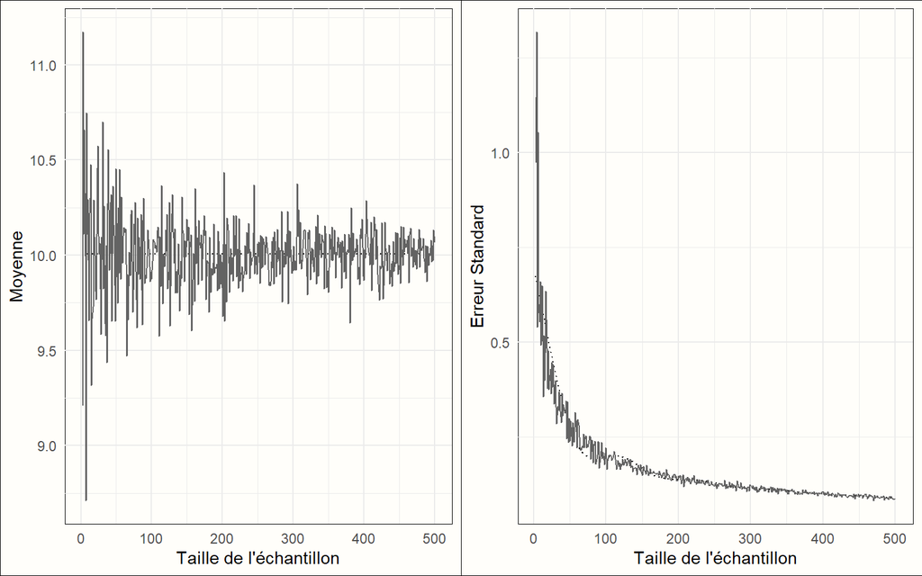

Figure 9.4: Moyenne et erreur-standard en fonction de la taille de l’échantillon

Nous avons donc tous les éléments nécessaires pour spécifier les caractéristiques de la distribution d’échantillonnage des moyennes:

- Il s’agit d’une distribution gaussienne, ou normale
- Sa moyenne est égale à la moyenne de la population ($\mu$)
- Son erreur standard est défini par l’équation Équation 9.3:

$$\sigma_{\overline{x}}=\frac{\sigma}{\sqrt{n}} \tag{9.3}$$

Ces énoncés forment l’essentiel du **Théorème Central-Limite** concernant la distribution d’échantillonnage d’une moyenne.

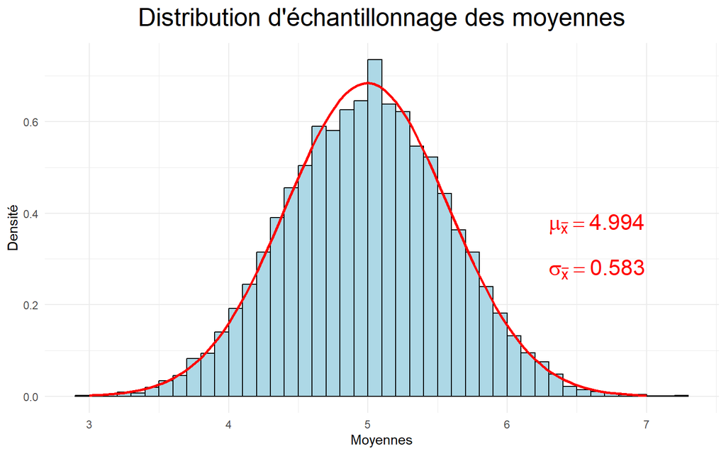

Figure 9.5: Normalité de la distribution des moyennes

On peut constater, au moins visuellement, que la distribution normale s’ajuste très bien à la distribution d’échantillonnage des moyennes. De manière plus formelle, la fonction **fitdist()** de la librairie **fitdistrplus** estime la moyenne et l’écart-type d’un ensemble de données, en supposant une distribution spécifique (normale dans le cas présent), et fournit des représentations graphiques permettant de juger de la normalité de la distribution. Il ne s’agit pas ici de calculer la moyenne et l’écart-type de la distribution, mais bien de déterminer si cette distribution pourrait être ‘normale’ et d’en spécifier les paramètres en supposant que c’est le cas. On constate que l’estimation obtenue est identique à ce que nous avons obtenu dans les calculs précédents:

```r
 FIT <- fitdistrplus::fitdist(dismoy, "norm")
 FIT
```

```
#> Fitting of the distribution ' norm ' by maximum likelihood
#> Parameters:
#>       estimate  Std. Error
#> mean 4.9944554 0.005829315
#> sd   0.5829315 0.004121893
```

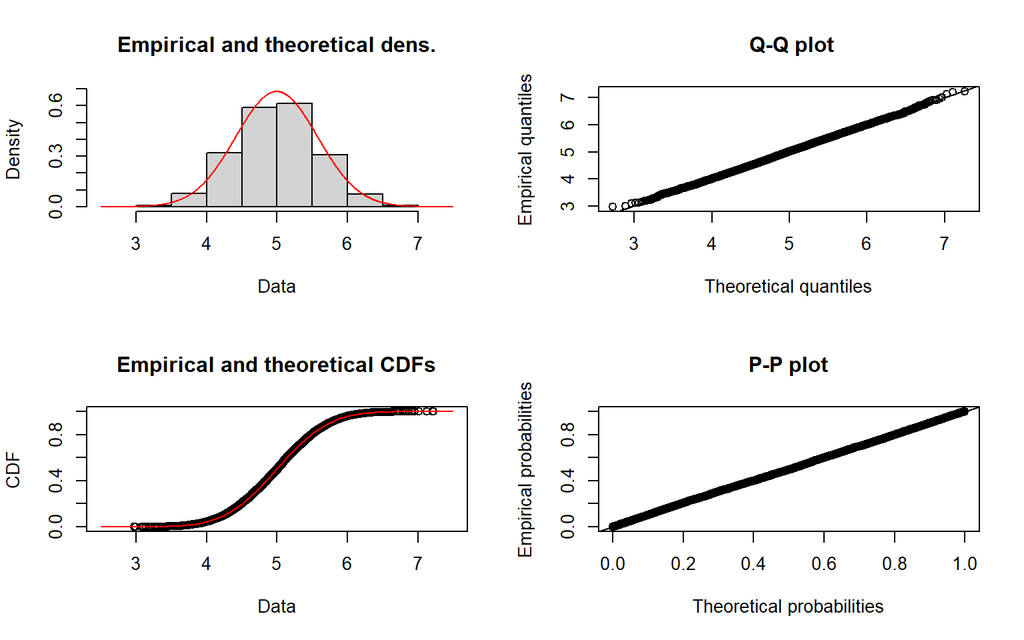

Ajustement de la loi normale à la distribution d’échantillonnage des moyennes, en utilisant la fonction **fitdist()** de la librairie **fitdistrplus**

```r
 plot(FIT)
```

Utilisant la fonction **fitdistr()** de la librairie **MASS** fournit des résultats identiques:

```r
fit <- MASS::fitdistr(dismoy, "normal")
fit$estimate
```

```
#>      mean        sd
#> 4.9944554 0.5829315
```

On constate que les paramètres obtenus sont identiques à la moyenne et à l’erreur-standard calculés précédemment.

À ce point, il ne devrait plus y avoir de doute concernant les caractéristiques de la distribution d’échantillonnage des moyennes. En bref, on peut étudier la distribution d’échantillonnage des moyennes

- en tirant un **très grand nombre d’échantillons** d’une population et en calculant la moyenne et l’écart-type des moyennes obtenues pour chaque échantillon, ou …
- en tirant **un seul échantillon** d’une population et en considérant le fait que la distribution d’échantillonnage ‘théorique’ a une moyenne égale à la moyenne de la population, et en calculant son erreur-standard à partir de l’écart-type de la population (s’il est connu) et la taille de l’échantillon.

Le problème avec cette seconde option, c’est que la moyenne de la population demeure inconnue. On ne peut que supposer que si on tirait un grand nombre d’échantillons de la population on obtiendrait ce résultat, mais l’expérience n’est pas réalisée, ni même généralement réalisable dans un contexte réel.

Lorsque les échantillons sont tirés d’une population finie, l’erreur standard des moyennes doit tenir compte du taux d’échantillonnage, défini par le rapport entre la taille de l’échantillon et la taille de la population:

$$Taux~~d'échantillonnage=\frac{n}{N} \tag{9.4}$$

$$\sigma_{\bar X}=\left [\frac{\sigma}{\sqrt{n}}\right ] \left [ \sqrt{\frac{N-n}{N-1}} \right ]=\left [\frac{\sigma}{\sqrt{n}}\right ] \left [ \sqrt{1-\color{red}{\frac{n}{N}}} \right ] \tag{9.5}$$

Le facteur par lequel l’erreur-standard est multiplié porte le nom de **coefficient d’exhaustivité**. Par exemple, supposons une population finie composée de $N=1000$ entités, dont l’écart-type est égal à 15. On tire un échantillon de 50 observations de cette population. On peut donc estimer l’erreur-standard des moyennes:

$$\sigma_{\bar X}=\left [\frac{15}{\sqrt{50}}\right ] \left [ \sqrt{1-\frac{50}{1000}} \right ]=2.1213 \times 0.9747=2.068$$

La correction se traduit par une légère diminution de l’erreur standard. Plus le taux d’échantillonnage est élevé (*n* est grand), plus le coefficient d’exhaustivité est faible et par conséquent, plus l’erreur-standard est petite. Par exemple, pour *n*=200, on a:

$$\sigma_{\bar X}=\left [\frac{15}{\sqrt{200}}\right ] \left [ \sqrt{1-\frac{200}{1000}} \right ]=1.0607 \times 0.8944=0.9487$$

Une telle correction devra être appliquée dans plusieurs situations où la population est finie.

### 9.2.3 Mise en application

Les caractéristiques de la distribution d’échantillonnage des moyennes ont pu être déterminées de manière analytique. Nous connaissons maintenant sa forme (gaussienne), sa moyenne (la moyenne de la population), et sa dispersion (l’erreur-standard des moyennes). De quelle manière peut-on tirer profit de ces connaissances pour procéder au calcul de probabilités?

Sous R, les fonctions suivantes nous aideront dans ce contexte:

- **dnorm(x, mean = 0, sd = 1)**: Fonction de densité (probabilité de x, x faisant partie d’une distribution normale dont la moyenne est nulle (par défaut) et son écart-type est l’unité (par défaut))
- **pnorm(x, mean = 0, sd = 1, lower.tail = TRUE)**: Probabilité cumulative, $P(-\infty<x)$, par défaut
- **qnorm(p, mean = 0, sd = 1, lower.tail = TRUE)**: Fonction quantile: X sous lequel on trouve $(100\times p)\%$ de la distribution
- **rnorm(n, mean = 0, sd = 1)**: Génération de nombres aléatoires normalement distribués avec $\mu=0$ et $\sigma=1$.

#### 9.2.3.1 Exemples:

Pour les besoins des exemples suivants, considérons une population de grande taille $N=500,000$, normalement distribuée. Le code R suivant génère une telle population.

```r
set.seed(150752)
N <- 500000
x <- rnorm(N, 50, 8)
m1 <- mean(x)
s1 <- sd(x)
```

La moyenne de cette population est $\mu = 50.026$ et $\sigma = 8$. Dans ces conditions,

1. Quelle est la probabilité que la moyenne d’un échantillon de taille $n=30$ tiré de cette population, soit supérieure à 52?

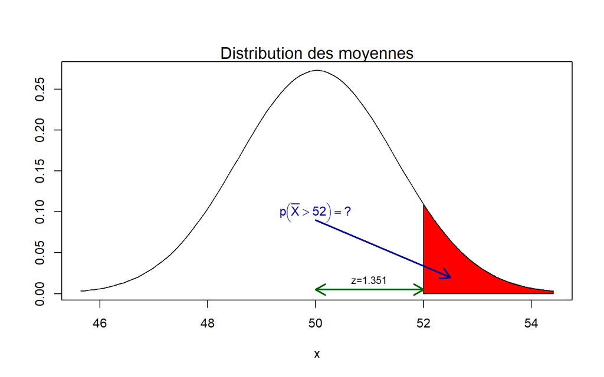

- Une première étape conduisant vers une solution consiste à standardiser la valeur considérée ($\bar X = 52$). Le score Z représente cette moyenne en unité d’erreur standard des moyennes:

$$\sigma_{\bar X}=\frac{\sigma}{\sqrt n}= \frac{ 8}{\sqrt {30}}=1.461$$

$$Z=\frac{\bar X - \mu}{\sigma_{\bar X}}=\frac{52-50.026}{1.461}=1.351$$

Dans la distribution d’échantillonnage des moyennes, une moyenne échantillonnale égale à 52 se trouve à 1.351 écart-type au-dessus de la moyenne de la population. Sous R, on peut obtenir ces résultats en utilisant le code suivant, évoquant la fonction **pnorm()** pour obtenir la probabilité recherchée:

$$\sigma_{\bar{X}}=1.461$$
$$z_{52}=1.351$$
$$P(\bar{X}>52) = 0.088$$

2. Quelle sont les limites d’un intervalle central comprenant 95% de la distribution des moyennes d’échantillons de taille *n*=30 observations? La situation est représentée dans la Figure 9.6:

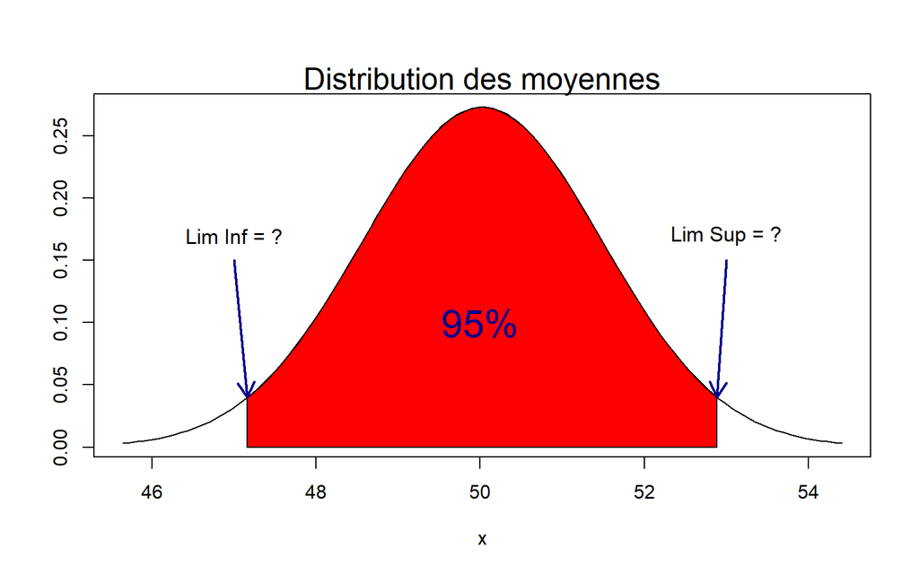

Figure 9.6: Intervalle comprenant 95% des moyennes, sous la distribution d’échantillonnage

Sous R, on propose deux manières de déterminer les valeurs limites recherchées:

- Utilisant la fonction **qnorm()** : si 95% de la distribution se trouve au centre, les deux extrémités contiennent chacune 2.5% de l’aire sous la courbe. On doit donc rechercher les percentiles $P_{2.5}$ et $P_{97.5}$, les premiers arguments de la fonction.

```r
liminf <- qnorm(0.025, m1, se)
limsup <- qnorm(0.975, m1, se)
```

$$P(47.164 \le \bar{X} \le 52.889)=0.95$$

On trouve donc qu’en tirant un échantillon de *n*=30 observations d’une population dont la moyenne est $\mu=50.026$ et l’écart-type est $\sigma_X=8$, on a 95% des chances que la moyenne de cet échantillon soit comprise entre 47.164 et 52.889.

## 9.3 Distribution d’échantillonnage des moyennes: Petits échantillons, $\sigma$ inconnu

Lorsque l’écart-type de la population est connu, notre niveau d’incertitude ne repose que sur les moyennes des observations: elles seules sont le fruit du hasard. Lorsque $\sigma$ est inconnu, ce qui est généralement le cas, la seule information dont nous disposons pour l’estimer est l’écart-type de l’échantillon ($s_x$), et ce faisant, puisque cette quantité est obtenue à partir de données aléatoires, nous ajoutons une part additionnelle d’incertitude à la situation: comme la moyenne, $s_x$ fluctue d’un échantillon à l’autre, et l’erreur d’échantillonnage s’applique autant à cette statistique qu’à la moyenne.

> Et il y a plus: lorsqu’un échantillon est de faible taille (*n* < 30, par exemple), son écart-type risque de sous-estimer l’écart-type de la population d’où il est tiré.

L’expérience suivante illustre ce fait. Pour *n* = {2:100}, on tire 10,000 échantillons d’une population normalement distribuée avec $\mu=100$ et $\sigma=15$. En calculant l’écart-type de chacun des échantillons d’une taille donnée, on obtient la distribution d’échantillonnage des écart-types dont on calcule la moyenne. Cette moyenne est la valeur de l’écart-type que l’on s’attend d’obtenir pour des échantillons d’une certaine taille, tirés de la population spécifiée. La Figure 9.7 résume les résultats de cette expérience: l’axe vertical représente la différence entre l’écart-type attendu et l’écart-type de la population, et l’axe horizontal représente la taille de l’échantillon (*n*).

Nous profitons de l’occasion pour visualiser l’impact de la correction de Bessel dans le calcul de l’écart-type d’un échantillon:

- Sans correction: $s_X=\sqrt{\frac{\sum{(X-\bar X)^2}}{n}}$
- Correction de Bessel: $s_X=\sqrt{\frac{\sum{(X-\bar X)^2}}{n-1}}$

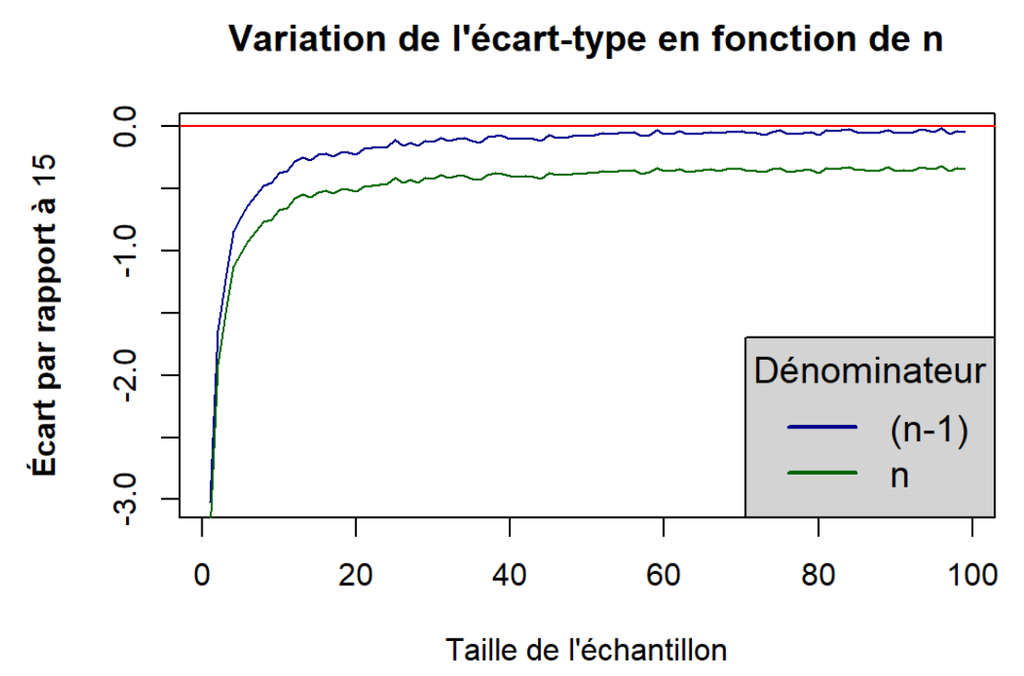

Figure 9.7: Estimation de l’écart-type de la population en fonction de la taille d’échantillon

La Figure 9.7 illustre que le fait d’appliquer cette correction (utiliser $n-1$ au dénominateur plutôt que $n$) permet de réduire le biais dans l’estimation de l’écart-type de la population à partir de données échantillonnales. On peut voir que si la correction n’est pas appliquée (courbe verte), la valeur de l’écart-type ne s’approche que très lentement de l’écart-type de la population et ne l’égalera que pour $n=\infty$. Par contre, l’application de la correction (ligne bleue) permet un rapprochement beaucoup plus rapide, la différence étant négligeable lorsque $n > 30$.

On note immédiatement que pour $n < 30$, la sous-estimation de la variation est importante. La conséquence de ce fait est que la distribution normale utilisée comme modèle théorique pour les calculs de probabilités relatives à la distribution d’échantillonnage des moyennes n’est plus appropriée lorsque les échantillons sont de faibles tailles. On doit trouver une distribution théorique permettant de corriger cette situation. Quelles seraient les caractéristiques d’une telle distribution? L’expérience suivante fournira quelques éléments de réponse.

Supposons une population infinie, normalement distribuée, dont la moyenne $\mu=50$, mais dont la dispersion est inconnue. On tire de cette population 100,000 échantillons de taille $n=5$, et pour chacun d’eux, on calcule la moyenne et l’écart-type, pour finalement calculer:

$$t=\frac{\bar X-\mu}{s/\sqrt{n}} \tag{9.6}$$

La valeur de $t$ est une valeur standardisée de la moyenne de l’échantillon, en fonction de l’écart-type de l’échantillon ($s$). On y reconnait une estimation de l’erreur-standard des moyennes, au dénominateur de sa définition.

On obtient donc 100,000 valeurs de $t$ et on établit sa distribution, illustrée dans la Figure 9.8. Dans cette figure, l’histogramme reproduit la distribution empirique des t calculés, alors que la courbe en rouge reproduit la distribution normale théorique.

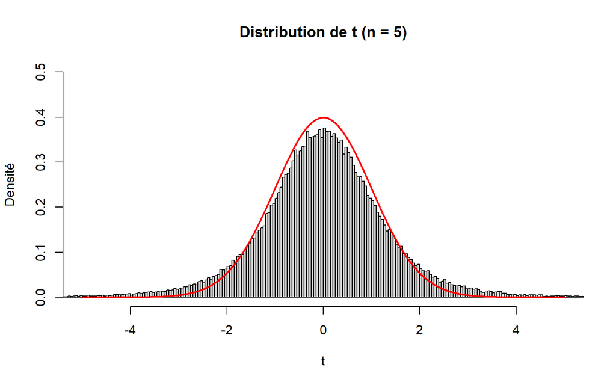

Figure 9.8: Distribution des valeurs de t observées pour des échantillons de taille n=5

On note une distribution symétrique qui semble de démarquer de la distribution normale en ce que ses extrémités sont plus lourdes, ce qui traduit une dispersion plus élevée que dans une distribution normale. En effet, l’écart-type des valeurs de $t$, $\sigma_t=1.415$, alors que $\sigma_z=1$. En conséquence, le calcul de probabilités fondé sur la distribution normale dans une telle situation fournirait de fausses réponses. Par contre, le problème serait moins prononcé si la taille des échantillons augmentait, comme on peut le constater dans la Figure 9.9, pour des échantillons de taille $n=50$.

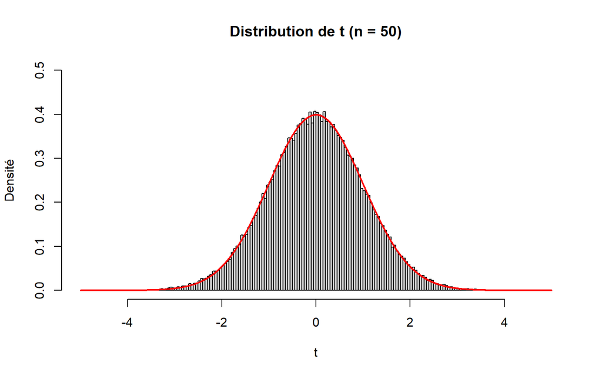

Figure 9.9: Distribution des valeurs de t observées pour des échantillons de taille n=50

On trouve, dans ce cas, $\sigma_t=1.016$, une valeur qui s’approche de la dispersion d’une distribution normale ($\sigma=1$).

Le modèle recherché doit donc posséder les caractéristiques suivantes:

- Symétrie: comme la distribution normale
- Centrée sur 0: comme la distribution normale standardisée
- Dispersion supérieure à la dispersion de la distribution normale standardisée
- Dispersion dépendante de la taille de l’échantillon.

La **distribution de Student** possède les caractéristiques nécessaires pour cette situation: comme la distribution normale standardisée, elle est symétrique avec une moyenne nulle, mais son écart-type est supérieur à 1.0. En effet, la dispersion de la distribution de Student dépend du nombre de degrés de liberté, reflet de la taille de l’échantillon. Plus la taille de l’échantillon est petite, plus l’écart-type de la distribution de Student est grand.

Le nombre de degrés de liberté ($dl$) sur lequel se fondent plusieurs distributions de probabilité théoriques, dont la distribution de Student, est simplement le nombre de valeurs qui sont libres de varier, dans le calcul d’une quantité donnée. Par exemple, si la somme de 5 scores est égale à 15, quatre d’entre eux peuvent prendre n’importe quelles valeurs, mais une fois ces valeurs fixées, le cinquième score est nécessairement déterminé: il n’est plus libre de varier. Le nombre de degrés de liberté dans ce cas est $dl=5-1=4$.

La distribution de Student varie donc en fonction du nombre de degrés de liberté, son écart-type décroissant avec toute augmentation de ce nombre, jusqu’à atteindre 1.0 lorsque $dl=\infty$. De fait, l’écart-type de la distribution de Student n’est défini qu’en terme du nombre de degrés de liberté, tel qu’explicite dans l’équation Équation 9.7:

$$\sigma_{t_{dl}}=\sqrt{\frac{dl}{dl-2}} \tag{9.7}$$

Pour $dl=5$, on trouve:

$$\sigma_{t_{5}}=\sqrt{\frac{5}{5-2}}=1.291$$
La Figure 9.10 illustre la variation de l’écart-type de la distribution de Student en fonction du nombre de degrés de liberté.

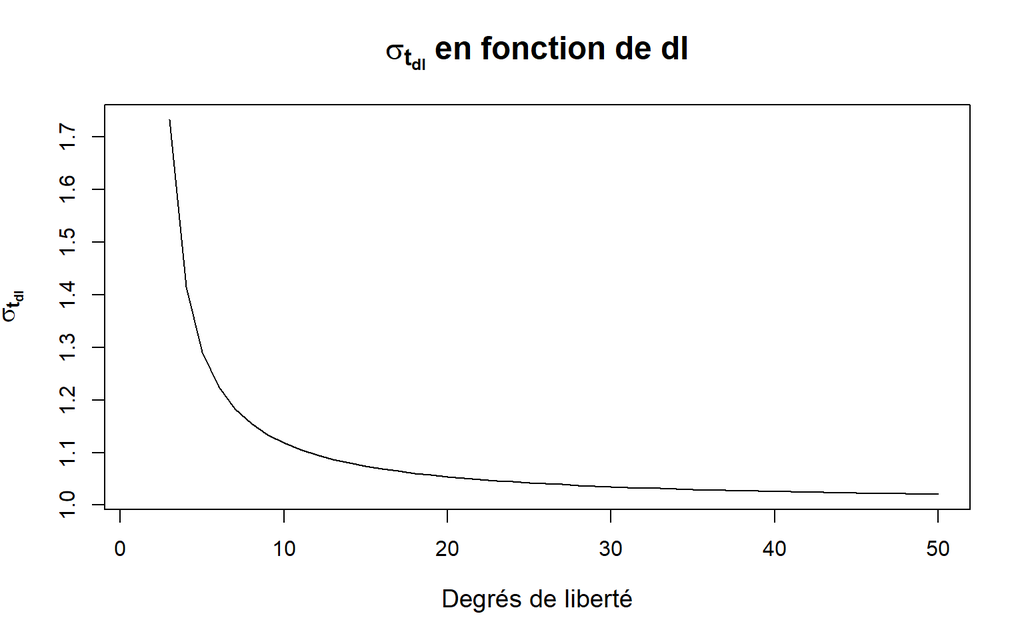

Figure 9.10: Variation de l’écart-type de la distribution de Student, en fonction du nombre de degrés de liberté

On note que lorsque $dl$ est supérieur à 25 ou 30, l’écart-type de la distribution est très près de 1.0, la valeur limite pour $dl=\infty$.

La Figure 9.11 présente les distributions de Student pour différents degrés de liberté:

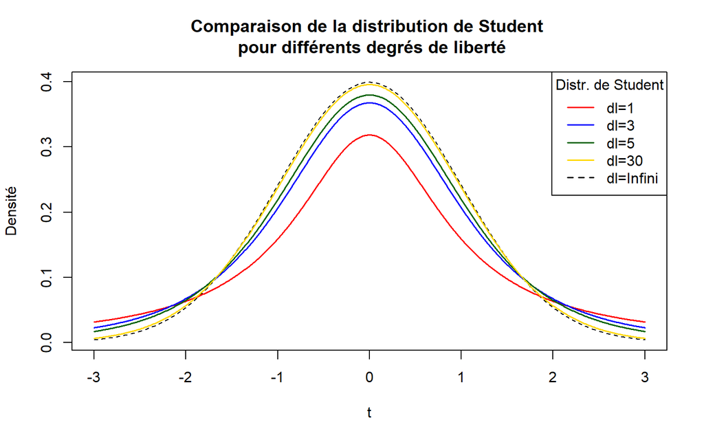

Figure 9.11: Distributions de Student pour différents degrés de liberté.

Plus le nombre de degrés de liberté est élevé, plus la distribution de Student s’approche de la distribution gaussienne. À la limite, pour $dl=\infty$, les deux distributions coïncident (courbe pointillée). En pratique, on peut noter que pour $dl=30$, la distribution de Student suit de très près la distribution normale.

Sous R, à l’instar des distributions de probabilité étudiées jusqu’à maintenant, un ensemble de fonctions facilitent les calculs de probabilités dont nous avons besoin:

1. **dt(x, dl)**: fonction de densité - Probabilité de x pour dl degrés de liberté
2. **pt(x, dl**, lower.tail=TRUE): fonction de probabilité cumulative
3. **qt(p, dl**, lower.tail=TRUE): fonction quantile: valeur de t sous (par défaut) laquelle on retrouve 100p% de la distribution
4. **rt(n, dl**): génération de nombres aléatoires

Exemple 1: Quelle proportion de la distribution se trouve sous t = 2.27, lorsque $dl=24$?

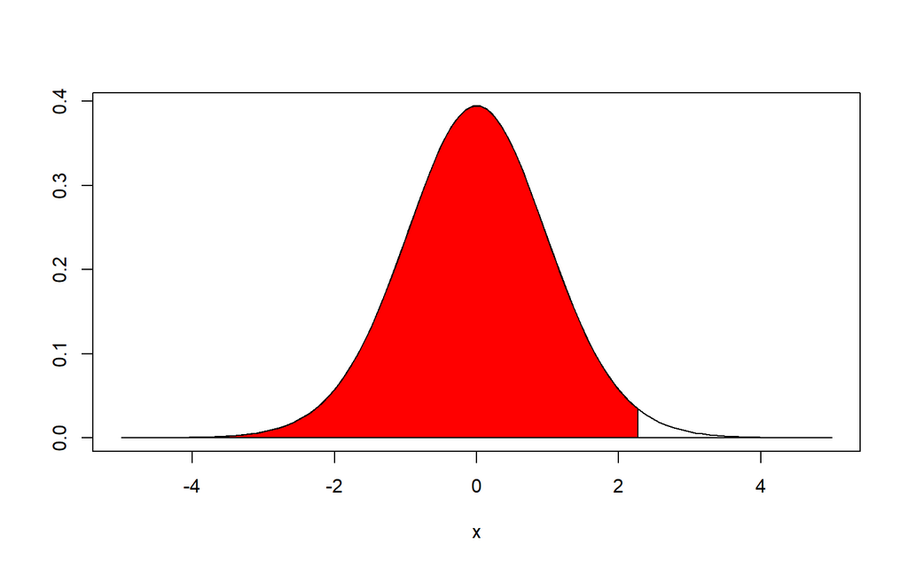

```r
t_area(df=24, ub=2.27, acolor="red")
```

```r
p <- pt(2.27, 24, lower.tail=TRUE)
```

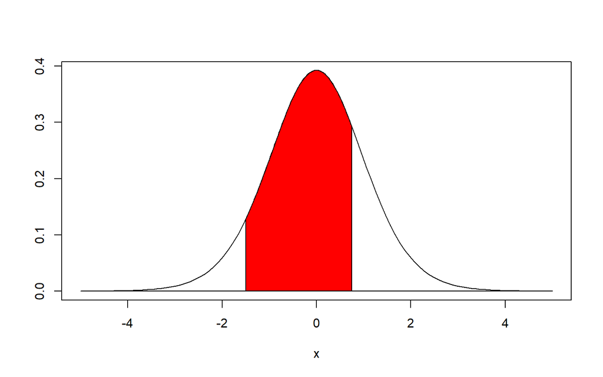

```r
t_area(df=15, lb=-1.5, ub=0.75, acolor="red")
```

```r
p1 <- pt(-1.5, df=15, lower.tail=TRUE)
p2 <- pt(0.75, df=15, lower.tail=TRUE )
pr <- p2 - p1
```

Exemple 3: Quelle est la probabilité que t soit supérieur à 1.96, lorsque $dl=5$?

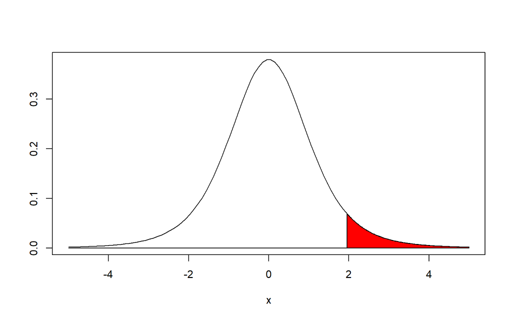

```r
t_area(df=5, lb=1.96, acolor="red")
```

```r
p1 <- pt(1.96, df=5, lower.tail=FALSE)
```

$$dl=5 :P(t>1.96) = 0.054$$

Exemple 4: Quelle proportion de la distribution se trouve sous t = 1.96, lorsque $dl=\infty$?

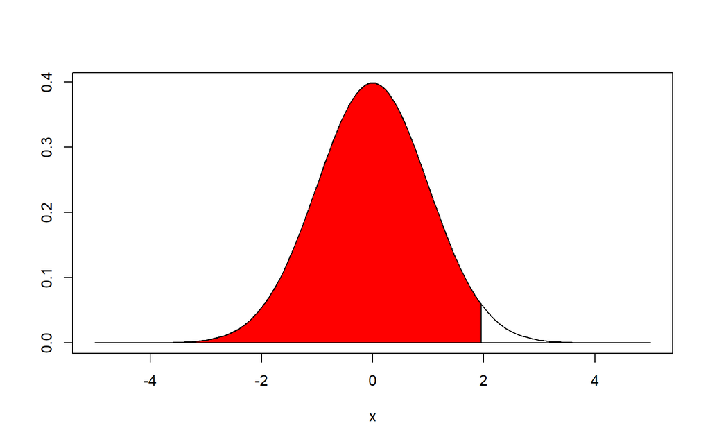

```r
t_area(df=Inf, ub=1.96, acolor="red")
```

```r
p1 <- pt(1.96, df=Inf, lower.tail=TRUE)
```

$$dl=\infty \; :P(t \le 1.96)=0.975$$

Ce dernier exemple illustre le fait que pour $dl=\infty$, les probabilités calculées à partir de la distribution de Student et celles obtenues de la distribution normale standardisée sont identiques:

```r
p2 <- pnorm(1.96, lower.tail=TRUE)
```

$$P(z \le 1.96)= 0.975$$

Exemple 3: Quel est le troisième quartile de la distribution de Student, pour $dl=10$?

```r
q <- qt(0.75, 10, lower.tail=TRUE)
```

$$dl = 10 \; : Q_3 = 0.7$$

### 9.3.1 Application DistrEchant

La manipulation et la visualisation de données est une activité importante pour parvenir à maîtriser les concepts pertinents à l’inférence statistique. Plusieurs applications, accessibles sur Internet, s’avèrent enrichissantes dans ce contexte. Le premier onglet de l’application [DistrEchant](https://daniel-coulombe.shinyapps.io/DistrEchant/) permet de visualiser et d’expérimenter diverses distributions d’échantillonnage, incluant la distribution des moyennes (par défaut). On pourra manipuler la distribution de la population (uniforme, normale, exponentielle et asymétrique positive) et ses paramètres, de même que la taille de l’échantillon et leur nombre. Le calcul des probabilités à l’aide de la distribution empirique est également possible à l’aide de cette application.

**MINI-QUIZ 2**

**Vrai ou Faux**:

- On peut s’attendre à ce que la moyenne de la distribution d’échantillonnage des moyennes, établie à partir d’un très grand nombre d’échantillons, soit sensiblement différente de la moyenne de la population ($\mu_X$)
- Plus l’écart-type de la population est grand, plus la valeur de l’erreur-standard des moyennes est faible
- De la même manière, plus la taille de l’échantillon est grande, plus la valeur de l’erreur-standard des moyennes est faible
- Lorsque la population est finie, l’erreur-standard des moyennes pourrait être supérieur à celui qu’on obtiendrait dans le cas d’une population infinie
- Comme la distribution normale, la distribution de Student est déterminée par sa moyenne et son écart-type

**Choix multiples**:

- Lorsque l’écart-type de la population est connu, la distribution de probabilité appropriée pour représenter une distribution d’échantillonnage de moyennes est la distribution:
- En tirant un grand nombre d’échantillons de taille $n=10$, d’une population distribuée de manière uniforme, avec un minimum de 10 et un maximum de 20, on obtient une distribution d’échantillonnage qui serait apparentée à la distribution
- En tirant un grand nombre d’échantillons de taille $n=1$, d’une population distribuée de manière uniforme, avec un minimum de 10 et un maximum de 20, on obtient une distribution d’échantillonnage qui serait apparentée à la distribution

## 9.4 Distribution d’échantillonnage des variances

De la même manière qu’on a pu établir la distribution d’échantillonnage des moyennes dans la section précédente, il est possible d’établir la distribution des variances. Cette distribution peut être produite en utilisant une approche empirique, par simulation, ou une approche analytique en utilisant une distribution de probabilité théorique pour autant que les postulats pertinents sont respectés.

### 9.4.1 Approche empirique

Comme dans le cas de la distribution des moyennes, on obtient la distribution d’échantillonnage des variances en tirant d’une population un grand nombre d’échantillons d’une certaine taille, en calculant la variance de chacun de ces échantillons, pour finalement établir la distribution des variances observées. Le code R suivant effectue ce travail: on tire 100,000 échantillons de taille *n*=5 tirées d’une distribution gaussienne ($\mu = 100, ~~\sigma = 15$), ce qui produit la Figure 9.12:

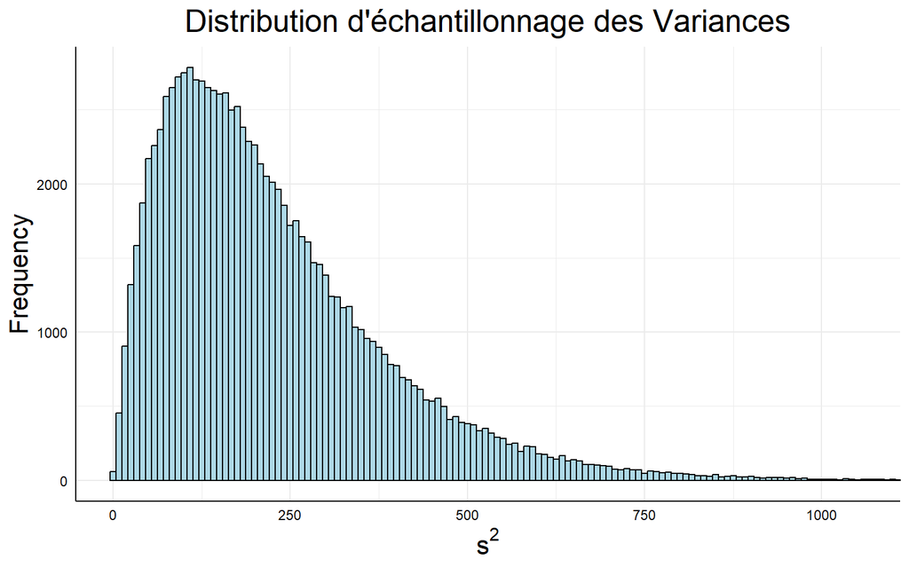

Figure 9.12: Distribution d’échantillonnage des variances

```r
nrep <- 100000
disvar <- replicate(nrep, var(rnorm(5, 100, 15)))
m1a <- mean(disvar)
s1a <- sd(disvar)
ska <- skewness(disvar)
kua <- kurtosis(disvar)

DistHist(disvar,
         stat = expression(s^2),
         title = "Distribution d'échantillonnage des Variances",
         col = "lightblue",
         xlim = c(0, quantile(disvar, 0.999)))
```

Les caractéristiques de cette distribution sont les suivantes:

$$\mu_{s^2}=225.061 \qquad \sigma_{s^2}=159.356$$
$$Sk_{s^2}=1.442 \qquad Ku_{s^2}=6.153$$

Dans un premier temps, on note que la moyenne de la distribution d’échantillonnage des variances est égale à la variance de la population (les échantillons sont tirés d’une distribution gaussienne dont l’écart-type est égal à 15, donc la variance est égale à 225). On pouvait s’attendre à un tel résultat.

En ce qui concerne l’erreur-standard de la distribution des variances, $\sigma_s=159.356$, elle est très différente de l’écart-type de la population ($\sigma_x=15$). Ce fait n’est nullement une surprise, puisque ces deux quantités concernent des variables aléatoires différentes et non directement comparables. Cependant, comme c’est le cas de l’erreur-standard des moyennes, on peut concevoir que la valeur de $\sigma_{s^2}$ pourrait dépendre de la taille de l’échantillon.

Finalement, qu’en est-il de la forme de la distribution d’échantillonnage des variances? Dans cette simulation, on utilise des échantillons de petite taille (*n* = 5) de manière à faire ressortir une caractéristique de la distribution d’échantillonnage des variances: elle est asymétrique positive! En effet, l’indice de symétrie [$Sk = 1.442$] a une valeur positive sensiblement éloignée de 0. On note également que la distribution est fortement leptokurtique, avec $Ku= 6.153$. Par contre, ces écarts par rapport à une distribution gaussienne décroissent en fonction de la taille de l’échantillon. Le tableau Table 9.2 résume la situation en répétant l’expérience pour *n* passant de 5 à {10, 25, 50, 100, 500}:

```r
nrep <- 100000
ns <- c(5, 10, 25, 50, 100, 500)

compute_stats <- function(n) {
  disvar2 <- replicate(nrep,
                       var(rnorm(n, 100, 15)))
  sk <- skewness(disvar2)
  ku <- kurtosis(disvar2)
  moy <- mean(disvar2)
  et <- sd(disvar2)
  return(c(n, moy, et, sk, ku))
}

stats <- t(sapply(ns, compute_stats))

df <- data.frame(stats)
colnames(df) <- c("n", "Moyenne", "Erreur Std", "Symétrie", "Voussure")

df %>%
  kbl(booktabs = TRUE,
      digits=3,
      caption = "Caractéristiques de la distribution d''échantillonnage des Variances, en fonction de n") %>%
  kable_styling(bootstrap_options = c("striped", "hover", "condensed"),
                full_width=FALSE) %>%
  column_spec(1, bold=TRUE)
```

Table 9.2: Caractéristiques de la distribution d''échantillonnage des Variances, en fonction de n

| n | Moyenne | Erreur Std | Symétrie | Voussure |
| --- | --- | --- | --- | --- |
| 5 | 225.193 | 159.106 | 1.424 | 6.130 |
| 10 | 224.844 | 106.228 | 0.952 | 4.361 |
| 25 | 224.958 | 64.810 | 0.584 | 3.533 |
| 50 | 224.975 | 45.394 | 0.401 | 3.223 |
| 100 | 225.198 | 32.094 | 0.273 | 3.107 |
| 500 | 225.030 | 14.262 | 0.125 | 3.031 |

De ce tableau, on note que la moyenne de la distribution des variances s’approche de la véritable variance de la population, quelle que soit la taille de l’échantillon. Ce résultat est attendu et analogue à ce qu’on a observé dans le cas de la distribution d’échantillonnage des moyennes. On note également que l’erreur standard de la distribution des variances diminue en fonction de la taille de l’échantillon, un résultat qui lui aussi était attendu.

Concernant la forme de la distribution, on constate que le degré d’asymétrie diminue en fonction de la taille de l’échantillon: pour $n=\infty$, la symétrie serait parfaite. On constate également que la distribution d’échantillonnage des variances est leptokurtique pour de faibles tailles d’échantillon, mais qu’une augmentation de cette taille se traduit à la limite, pour $n=\infty$, par une distribution mésokurtique ($Ku=3.0$).

Une autre caractéristique de cette distribution qu’on doit noter est qu’étant donné qu’une variance ne peut être négative, l’ensemble de la distribution est localisé du côté positif, ce qui n’est pas nécessairement le cas pour la distribution d’échantillonnage des moyennes.

```r
pr <- mean(disvar > 300)
```

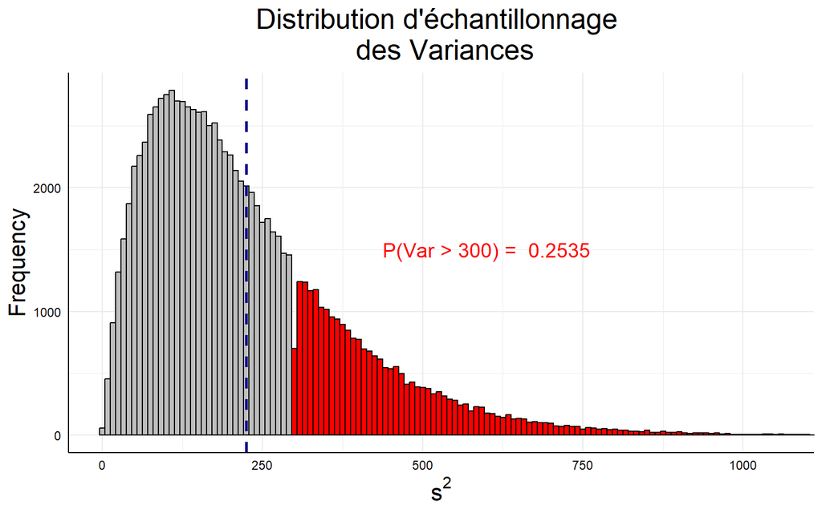

Figure 9.13: Distribution d’échantillonnage des variances pour n=5. On recherche la probabilité d’obtenir une variance supérieure à 300, pour un échantillon aléatoire tiré d’une population normalement distribuée. La ligne verticale indique la position de la moyenne de la distribution, approximativement égale à la variance de la population.

La distribution d’échantillonnage des variances se démarque donc de la distribution d’échantillonnage des moyennes quant à sa forme. Cette dernière s’ajuste très bien à une distribution gaussienne, ce qui n’est pas le cas de la première, sauf lorsque la taille de l’échantillon est infinie.

### 9.4.2 Approche analytique

De manière analytique, il est possible d’obtenir les caractéristiques de la distribution d’échantillonnage des moyennes: il suffit de se rappeler le théorème central limite! Mais qu’en est-il de la distribution d’échantillonnage des variances? Par quelle formulation mathématique pouvons-nous établir les caractéristiques de cette distribution? On sait que sa forme est asymétrique positive, et que sa moyenne est égale à la variance de la population, mais quelle est son erreur standard?

Une distribution de probabilité théorique susceptible d’être un modèle pour la distribution d’échantillonnage des variances doit être asymétrique positive, cette asymétrie diminuant en fonction de la taille de l’échantillon. La distribution normale est donc à exclure pour ce poste. La distribution exponentielle est asymétrique positive et la variable aléatoire qu’elle concerne ne prend que des valeurs positives, ce qui semblerait correspondre à ce que l’on recherche. Mais malheureusement, elle ne s’applique que lorsque les événements évalués surviennent dans un intervalle de temps ou un espace bien délimité. Et ce n’est pas le cas de la variance d’un échantillon. On doit donc introduire une autre distribution de probabilité qui pourrait très bien remplir le rôle dans le présent contexte: la distribution du $\chi^2$, **chi carré** (ou du **chi-deux**, selon les auteurs). Cette distribution ne s’ajuste pas très bien à la distribution des variances telle que définie plus haut. On doit en quelque sorte *standardiser* les variances, un peu comme on l’a fait avec les moyennes en les transformant en scores Z ou en $t$. La transformation nécessaire se définit par la relation:

$$\chi^2=\frac{(n-1)s^2}{\sigma^2} \tag{9.8}$$

Dans cette équation, $s^2$ correspond à la variance de l’échantillon, et $\sigma^2$ représente la variance de la population.

Examinons l’impact de cette transformation sur la distribution des variances, à l’aide d’une simulation. Des échantillons ($k=100,000$) de taille *n*=25 sont tirés d’une population distribuée normalement avec une moyenne $\mu=100$ et un écart-type $\sigma=15$. La Figure 9.14 affiche la distribution des variances originales, avant la transformation:

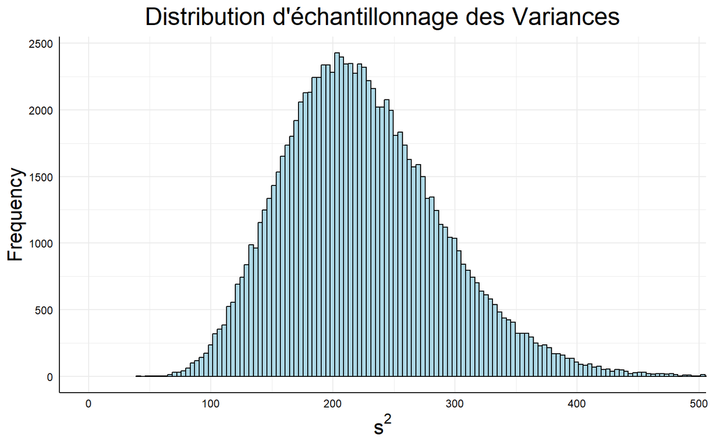

Figure 9.14: Distribution d’échantillonnage des variances avant la transformation en chi-carré

```r
 nrep <- 100000  # Nombre d'échantillons à tirer
 disvar <- replicate(nrep,var(rnorm(25, 100, 15)))
 mvar <- mean(disvar)
 svar <- sd(disvar)
 kuvar <- kurtosis(disvar)
 skvar <- skewness(disvar)
```

Les paramètres de cette distribution sont:

$$\mu_{s^2}=225.045 \qquad \sigma_{s^2}=64.863$$
$$Sk_{s^2}=0.589 \qquad Ku=3.579$$

Tel qu’observé précédemment, la distribution est asymétrique positive. La moyenne de cette distribution est $\mu_{s^2}=225.045$ et son erreur-standard est $\sigma_{s^2}=64.863$. On note que cette moyenne est au moins approximativement égale à la variance de la population. On peut croire que le lien entre son erreur-standard et la taille de l’échantillon existe, comme d’est le cas pour $\sigma{\bar{X}}$, mais sa nature demeure indéterminée.

Examinons la distribution des variances transformées en $\chi^2$, reproduite dans la Figure 9.15.

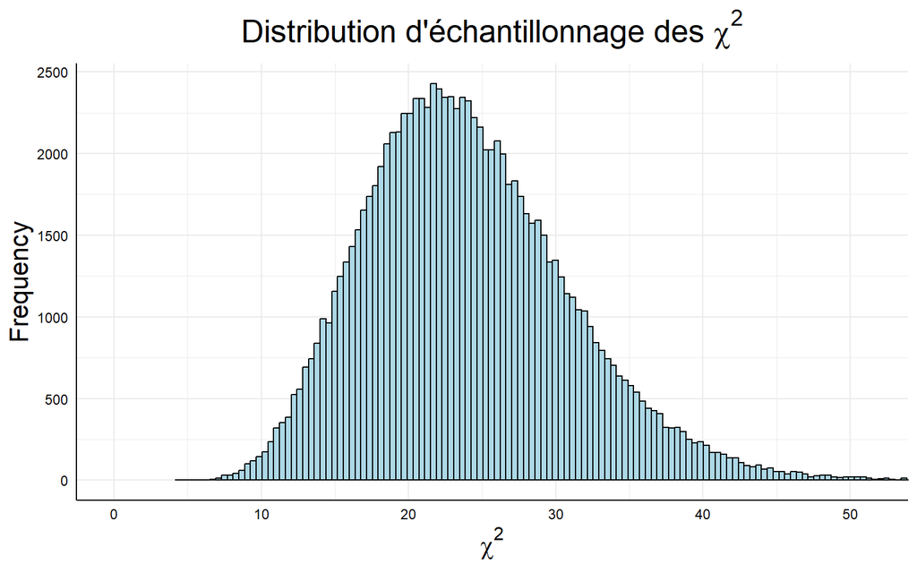

Figure 9.15: Distribution d’échantillonnage du Chi-carré (variances transformées)

```r
chi2 <- 24 * disvar / 225      # chi-carré = [(n-1)s^2]/Var(X)
mchi <- mean(chi2)
schi <- sd(chi2)
kuchi <- kurtosis(chi2)
skchi <- skewness(chi2)
```

Les paramètres de cette distribution sont:

$$\mu_{\chi^2}=24.005 \qquad \sigma_{\chi^2}=6.919$$
$$Sk_{\chi^2}=0.589 \qquad Ku_{\chi^2}=3.579$$

On note immédiatement que la forme de la distribution demeure inchangée. La nature de la transformation ne contient aucun élément susceptible d’altérer cette forme (rappelons que c’était aussi le cas lors de la transformation d’une distribution de scores bruts en scores Z!).

En ce qui concerne la moyenne de la distribution du $\chi^2$, un fait important émerge: elle est essentiellement égale à $(n-1)$. Cette quantité, porte un nom omniprésent en méthodes quantitatives et qu’on a déjà rencontré à quelques reprises. Il s’agit du nombre de **degrés de liberté**. Il s’agit simplement du nombre de données qui sont libres de varier, lors de la détermination d’une statistique ou d’un paramètre. Par exemple, considérons un ensemble de scores dont la somme est égale à 10: {2, 4, 3, 1}. Dans ce cas, *n* = 4. Mais pour que la somme des nombres soit égale à 10, il n’est nécessaire de connaître que 3 de ces valeurs; une fois fixées trois données, la quatrième n’est plus libre de varier. Le nombre de degrés de liberté est donc égal à 3.

Donc, il semble que la moyenne de la distribution du $\chi^2$ ($\mu_{\chi^2}=24$) soit égale au nombre de degrés de liberté ($dl=n-1=25-1=24$).

Dans le cas présent, la variance de la distribution est $\sigma_{\chi^2}^2$ = 47.868. Cette quantité est au moins approximativement égale à 2 fois la moyenne. Et finalement, on peut évaluer le degré d’asymétrie en fonction de la taille de l’échantillon: $Sk=\sqrt{8/dl}$, et le degré de voussure: $Ku_{\chi^2}=12/dl$. On peut donc écrire:

$$\begin{align}
\mu_{\chi^2} &= dl = n-1=24\\
\sigma_{\chi^2}^2 &= 2dl=2(n-1)=48\\
Sk_{\chi^2}&=\sqrt{8/dl}={8/24}=0.577\\
Ku_{\chi^2}&=12/dl=12/24=0.5
\end{align}
\tag{9.9}$$

En considérant la distribution théorique, le lien entre la taille de l’échantillon et la forme de la distribution devient explicite. On considère que pour des échantillons de grandes tailles (n > 100),

$$\chi^{2}_{dl}\approx N(dl,\sqrt {2dl})$$
La Figure 9.16 illustre cette distribution pour différents nombres de degrés de liberté:

[figure not shown]

Figure 9.16: Distribution du Chi-Carré pour différents nombres de degrés de liberté

L’impact de la taille de l’échantillon, déterminant *dl*, est manifeste. Et pour chacune de ces distributions, on peut déterminer de manière analytique la moyenne, l’écart-type et l’indice de symétrie.

À l’instar des autres distributions de probabilité que nous avons examinées jusqu’à maintenant, R offre un ensemble de fonctions nous permettant les calculs de probabilité que nous serons amenés à effectuer. Ces fonctions sont:

- **dchisq(x, dl)**: Fonction de densité (probabilité) de $\chi^{2}_{dl}$
- **pchisq(x, dl, lower.tail=TRUE)**: Fonction de probabilité cumulative $[P(0 \le \chi^{2}_{dl} \le x)]$
- **qchisq(p, dl, lower.tail=TRUE)**: Fonction quantile - Valeur de $\chi^{2}_{dl}$ sous laquelle on trouve $(100 \times p)\%$ de la distribution
- **rchisq(n, dl)**: Génération de nombres aléatoires

#### 9.4.2.1 Calculs de probabilités sous la distribution du $\chi^2$

Considérons la distribution d’échantillonnage de variances affichée dans la Figure 9.14, obtenue à l’aide d’échantillons de taille *n*=25. Le nombre de degrés de liberté est donc $dl=25-1=24$. Ces variances ont été transformées en $\chi^2$ et leur distribution a été formée et présentée à la Figure 9.17.

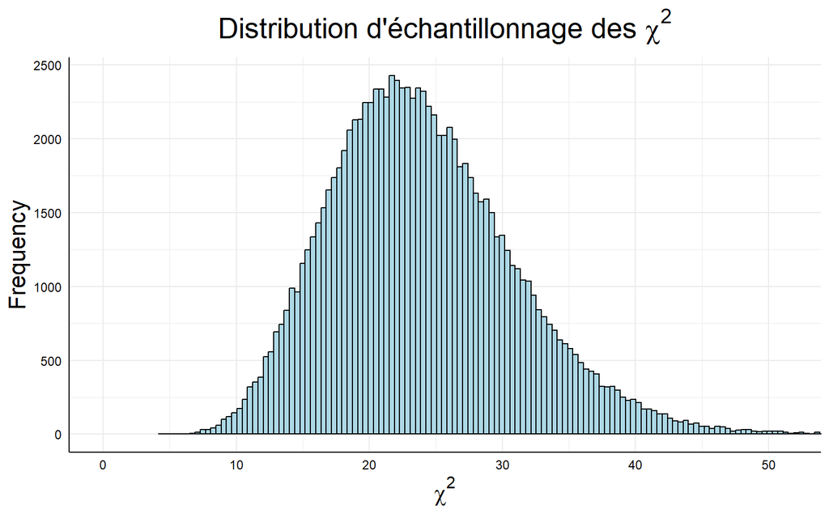

Figure 9.17: Distribution d’échantillonnage du chi-carré pour dl=24

```r
DistHist(chi2,
         lb = NULL,
         ub = NULL,
         stat = expression(chi^2),
         title = TeX(r'(Distribution d'échantillonnage des $\chi^2$)'),
         col = "lightblue",
         xlim = c(0, quantile(chi2, 0.999)))
```

À partir de cette distribution empirique, quelle est la probabilité qu’un échantillon de taille *n*=25 produise un $\chi^2>35$?

Comptabilisant toutes les valeurs de $\chi^2$ qui sont supérieures à 35, on trouve, tel qu’illustré dans la Figure 9.18:

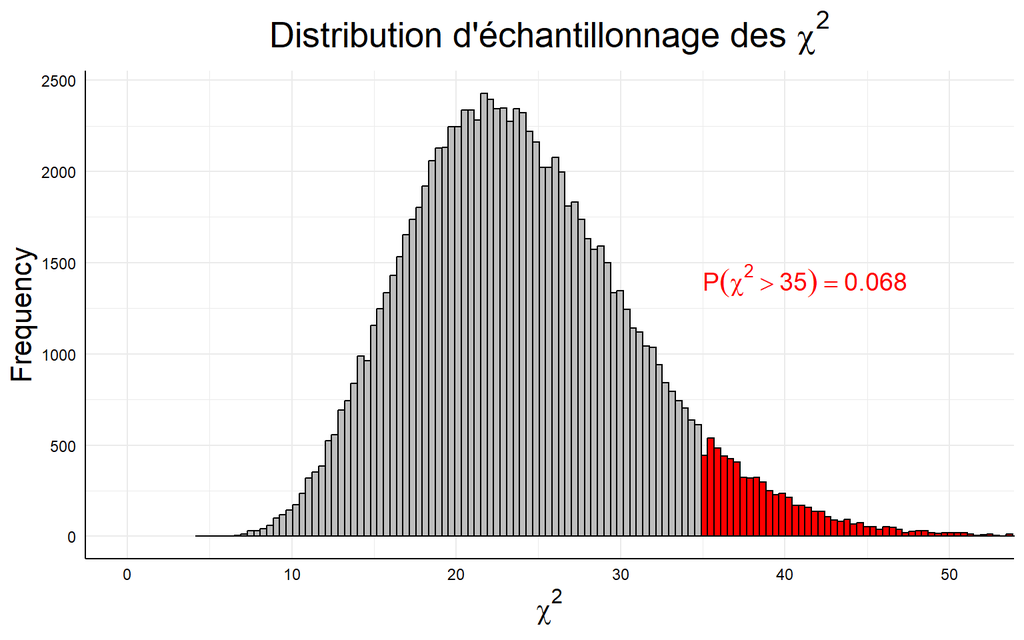

Figure 9.18: Distribution du Chi-carré pour dl=24

Vérifions ce résultat en utilisant la distribution théorique du $\chi^2$, tel qu’affiché dans la Figure 9.19 :

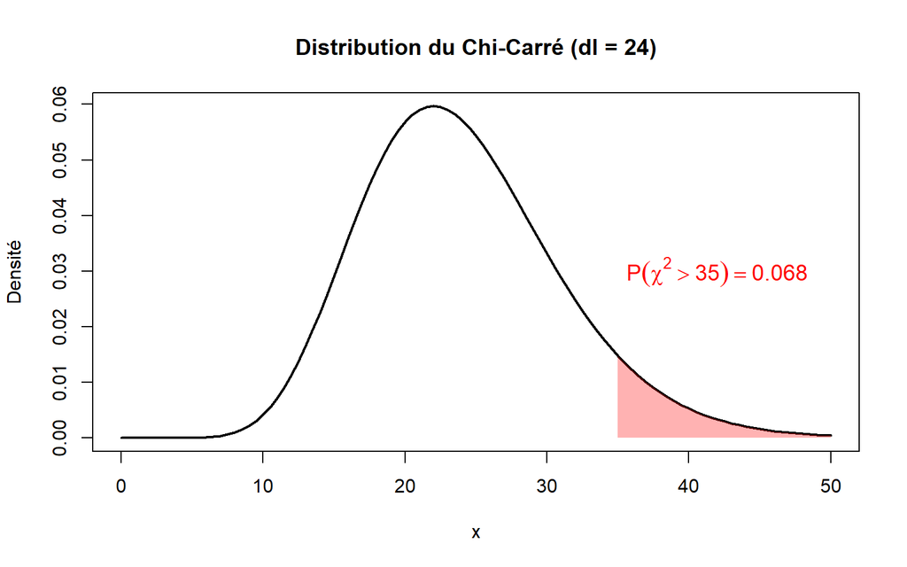

Figure 9.19: Distribution du Chi-carré, pour dl=24

On obtient des résultats qui ne laissent aucune place à une quelconque ombre de divergence! Il semble donc que la distribution du $\chi^2$ soit un modèle adéquat pour la distribution d’échantillonnage des variances, pour autant que certains postulats soient respectés. Un postulat (condition, ou prérequis) important dans la présente situation concerne la normalité de la distribution de la population. L’adéquacité de la distribution du $\chi^2$ comme modèle de probabilité pour la représentation de la distribution d’échantillonnage des variances repose fortement sur ce postulat. Pour s’en convaincre, reprenons l’expérience précédente, mais cette fois en tirant les échantillons (toujours de taille *n*=25) d’une distribution uniforme. Les résultats sont présentés dans la Figure 9.20.

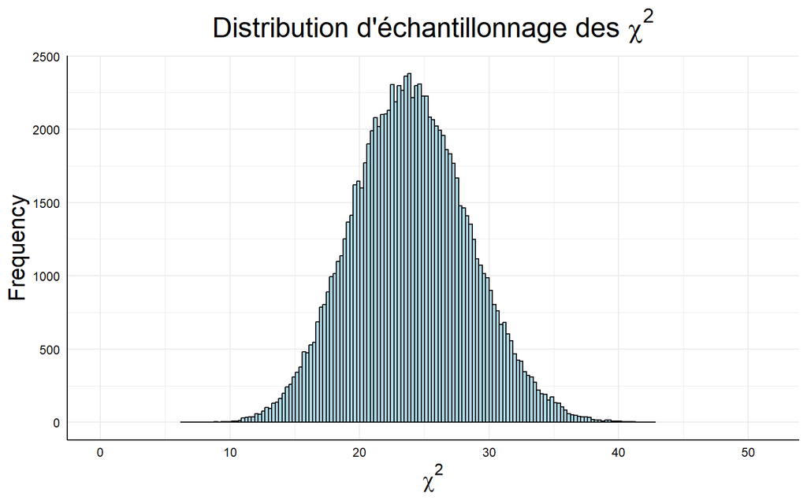

Figure 9.20: Distribution du Chi-carré pour des échantillons tirés d’une distribution uniforme (n=25)

```r
nrep <- 100000
disvar <- replicate(nrep, var(runif(25, 0, 10)))

chi2unif <- 24*disvar/8.333 # var(X) = (1/12)(10-0)**2

DistHist(chi2unif,
         lb = NULL,
         ub = NULL,
         stat = expression(chi^2),
         title = TeX(r'(Distribution d'échantillonnage des $\chi^2$)'),
         col = "lightblue",
         xlim = c(0, quantile(chi2, 0.999)))
```

De cette distribution empirique, calculons la probabilité que $\chi^2$ soit supérieur à 35 en comptabilisant les valeurs se trouvant dans cette zone, divisé par le nombre total de valeurs ($k=100,000$):

```r
p <- sum(chi2unif > 35)/nrep
```

$$P(\chi_{24}^2>35)=0.009$$
Calculons la même probabilité à l’aide de la distribution théorique du $\chi^2$. On obtient alors:

```r
p <- pchisq(35, 24, lower.tail=FALSE)
```

$$P(\chi_{24}^2>35)=0.068$$

Le tableau Table 9.3 présente les principaux paramètres d’une distribution de $\chi^2$ et leur définition théorique, tel qu’énoncé au paragraphe précédent. Des échantillons ($k_1=100,000$) sont tirés d’une distribution normale, et d’autres ($k_2=100,000)$ sont tirés dune distribution uniforme. Pour chacun des échantillons, on calcule la variance, que l’on transforme en $\chi^2$. En se fondant sur la définition théorique de la distribution du $\chi^2$, on devrait obtenir empiriquement des résultats similaires aux valeurs occupant la colonne libellée **Théorique**. On note que la distribution dérivée d’échantillons tirés d’une distribution normale (** Empir Norm**) présente des valeurs rapprochées des valeurs attendues. Par contre, lorsque les échantillons sont tirés d’une distribution uniforme, les résultats indiquent le contraire. On peut donc conclure que la normalité de la distribution de la population est un prérequis important des inférences portant sur la variance.

Table 9.3: Comparaison entre les paramètres obtenus par simulation à ceux dérivés de la distribution théorique du Chi-Carré. Les échantillons sont tirés d'une population normalement distribuée (**Empir Norm**) ou uniformément distribuée (**Empir Unif**).

| Paramètre | Équation | Théorique | Empir Norm | Empir Unif |
| --- | --- | --- | --- | --- |
| Moyenne | dl | 24.000 | 24.005 | 23.968 |
| Variance | 2dl | 48.000 | 47.868 | 20.296 |
| Écart-Type | SQRT(2dl) | 6.928 | 6.919 | 4.505 |
| Symétrie | SQRT(8/dl) | 0.577 | 0.589 | 0.127 |
| Voussure (centrée) | 12/dl | 0.500 | 0.579 | -0.044 |

De cette expérience, il ressort que la distribution du $\chi^2$ ne permet pas une représentation adéquate de la distribution d’échantillonnage des variances, lorsque la distribution de la population dévie fortement de la normalité. Par contre, les probabilités obtenues par simulation demeurent correctes!

Un dernier point à noter concerne le fait que la forme d’une distribution d’échantillonnage varie en fonction de la nature de la statistique qui la compose. On a en effet pu constater que dans le cas des moyennes, la distribution normale et la distribution de Student trouvent application, alors que dans le cas des variances, la distribution du $\chi^2$ est davantage approprié. Dans les prochains chapitres, il sera nécessaire de faire appel à plusieurs autres distributions de probabilité pour rendre compte de la spécificité de la distribution de certaines statistiques. Cependant, peu importe la forme que prendront ces distributions, le calcul des probabilités dont on a besoin dans un contexte particulier se feront toujours de la même manière.

**MINI-QUIZ 3**

**Vrai ou Faux**:

- La distribution d’échantillonnage des variances suit une distribution normale
- La distribution d’échantillonnage des variances est généralement asymétrique.
- La moyenne de la distribution d’échantillonnage des variances est égale à la variance de la population.
- Plus la taille de l’échantillon est grande, plus la distribution d’échantillonnage des variances devient large.
- Plus la taille de l’échantillon est grande, moins la distribution d’échantillonnage des variances est asymétrique
- Dans une distribution d’échantillonnage de variances transformées en $\chi^2$, on note généralement une asymétrie moindre que dans la distribution sans transformation
- Le nombre de degrés de liberté dans la distribution d’échantillonnage des variances sont égaux au nombre d’observations moins un.
- Lorsque la population d’où sont tirés les échantillons ne suit pas une distribution normale, les probabilités obtenues à partir de la distribution de probabilités appropriée sont généralement précises
- La variance de la distribution d’échantillonnage des variances obtenue par simulation est au moins approximativement égale à la variance de la population
- Si une variable aléatoire suit une distribution d’échantillonnage des variances, elle ne peut que prendre des valeurs positives.

**Choix multiples**:

- Quelle distribution est utilisée pour estimer la distribution d’échantillonnage des variances ?
- Quelle est la relation entre la distribution d’échantillonnage des variances et la distribution du chi-carré ?

  Elles sont identiquesElles sont proportionnellesLa distribution du chi-carré est un cas spécial de la distribution d'échantillonnage des variances La distribution d'échantillonnage des variances est un cas spécial de la distribution du chi-carré
- Quel est le nom de la distribution qui est obtenue lorsque la somme des carrés des écarts à la moyenne est divisée par la variance de la population ?
- Quelle est la relation entre la variance de la population et la moyenne de la distribution d’échantillonnage des variances ?

  Ces deux quantités sont égalesIl n'y a pas de relation entre ces quantités: la première mesure la dispersion, et la seconde la tendance centrale de la distributionLa racine carrée de la variance est égale à la moyenne, lorsque la taille des échantillons est grandeLe carré de la moyenne est égal à la variance de la distribution
- Le(s) paramètre(s) de la distribution du $\chi^2$ est(sont):

  la moyenne et l'écart-typela moyenne, l'écart-type et la taille de l'échantillonuniquement la moyenne de la distribution, si cette dernière est normalele nombre de degrés de liberté

## 9.5 Distribution d’échantillonnage des proportions

Une proportion est de fait la moyenne d’une variable de Bernouilli n’offrant que deux réponses possibles: 1 = ‘succès’, 0 = ‘échec’. Il n’est donc pas surprenant de constater que la distribution d’échantillonnage d’une proportion possède un lien de parenté avec la distribution d’échantillonnage d’une moyenne. Les détails relatifs à cette distribution sont présentés dans les paragraphes suivants.

### 9.5.1 Approche empirique

Supposons que dans la population des étudiant(e)s haïtien(ne)s inscrit(e)s dans un programme d’études supérieures, on s’intéresse à la proportion des personnes qui possèdent un ordinateur personnel. On crée une variable dont les valeurs sont (1) si la personne possède un ordinateur, et (0) si elle n’en possède pas. Nous sommes donc en présence d’une variable dichotomique, ou binaire. Il s’agit d’une variable nominale n’offrant qu’une seule option de calcul numérique: la comptabilisation des fréquences et éventuellement, le calcul d’une proportion. Par exemple, la proportion des individus possédant un ordinateur est égale au nombre d’individus pour qui c’est le cas, divisé par le nombre total d’individus dans la population.

Plusieurs questions de recherche scientifique s’intéressent à de telles variables et dans ces cas, la proportion occupée par une de deux catégories au niveau de la population devient un paramètre à étudier.

Rappelons qu’une distribution binomiale résultant d’un certain nombre d’essais (observations faites chez les étudiants de niveaux supérieurs) présuppose que:

- des essais produisent l’un ou l’autre de 2 résultats (être en possession d’un ordinateur, ou non)
- la probabilité d’un succès est la même d’un essai à l’autre (on suppose que la probabilité de posséder un ordinateur est égale pour chaque étudiant)
- les essais sont indépendants l’un de l’autre (le fait qu’un étudiant possède un ordinateur n’affecte pas la probabilité qu’un autre étudiant en possède un).

Si ces conditions sont respectées, alors la distribution binomiale est caractérisée par:

- l’espérance mathématique (la moyenne) est égale à $\mu_X = np$, $n$ étant le nombre d’essais (taille de la population ou de l’échantillon), et $p$ est la probabilité d’un ‘succès’ (obtenir ‘1’)
- l”écart-type de la distribution est égale à $\sigma_X=\sqrt{np(1-p)}$

Le code R suivant génère une population d’observations effectuées auprès d’étudiant(e)s des cycles supérieurs en Haïti, à savoir si oui (x = 1) ou non (x = 0) ils/elles ont un ordinateur en leur possession. Considérons cette population comme étant infinie (de très grande taille: N = 200,000), pour l’instant.

```r
set.seed(150752)
#| code-fold: false

pr <- 0.72
N <- 200000
Xpr <- sample(0:1, 200000, replace=TRUE, prob=c(1-pr, pr))
pi_p <- mean(Xpr)
```

Au niveau de cette population, la probabilité de posséder un ordinateur est $\pi=0.7177$, paramètre qui est généralement inconnu.

La variable **Xpr** contient l’ensemble des observations colligées auprès de la population. De cette population, tirons un échantillon de 100 observations, pour ensuite calculer la proportion de propriétaires d’ordinateurs:

```r
xech <- sample(Xpr, 100, replace=FALSE)
pr <- mean(xech)
```

$$P(x=1)=0.71$$

On sait déjà que la proportion observée pour cet échantillon n’est qu’un reflet de la véritable proportion au niveau de la population. Nous ne sommes donc pas surpris d’obtenir une proportion différente de celle qu’on retrouve au niveau de la population.

```r
nrep <- 100000
distprop <- replicate(nrep, mean(sample(Xpr, 100, replace=FALSE)))
mp <- mean(distprop)
sp <- sd(distprop)
```

La moyenne de cette distributon, $\mu_p=0.7179$, est approximativement égale à $\pi$, et son écart-type correspond à l’erreur-standard des proportions, $\sigma_p=0.0449$.

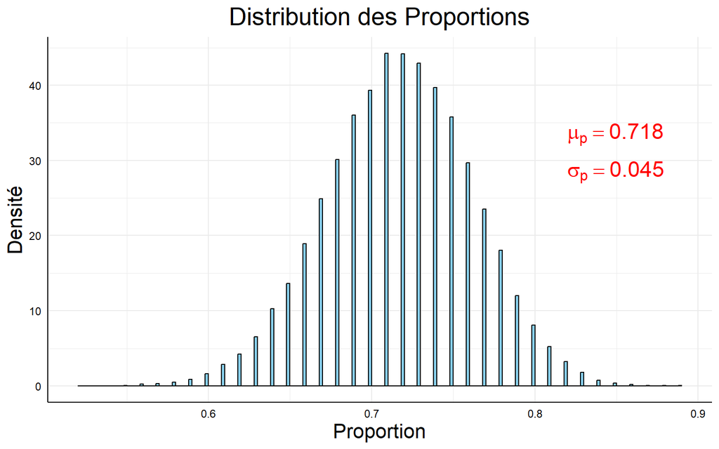

Figure 9.21: Distribution d’échantillonnage des proportions

De cette expérience, on note que la forme de la distribution d’échantillonnage des proportions s’apparente à une distribution gaussienne (c’est en fait une distribution binomiale), avec une moyenne égale à la proportion de la population des étudiants des niveaux supérieurs possédant un ordinateur. Cette proportion serait au moins approximativement égale à 0.718, avec une erreur-standard approximativement égale à 0.045. On sait que la proportion des propriétaires d’ordinateur au niveau de la population est égale à $\mu_p=0.718$. On peut donc affirmer avec confiance que la moyenne de la distribution d’échantillonnage des proportions est égale, à la limite (ie pour un nombre infini d’échantillons de taille *n*), à la proportion au niveau de la population.

À partir de cette distribution, obtenir les probabilités relatives aux proportions est une opération triviale. Par exemple,